# Within-host diversity analyses in SARS-CoV-2

##1. Mutational spectra and load

####Input files

```r
mutations_file = "./data/shearwater_intermediate_intersect_muts_both_runs_annotated_median_values_deltaVAF0.05_merge.rds"
metadata_file = "./data/replicate_meta.tsv"
mutations = readRDS(mutations_file)
exclude_samples = c("CAMB-728D4","CAMB-79345")
```

Reformatting the mutation file and adding sequence context information.

```r
mutations$chr = "MN908947.3"; mutations$sampleID = mutations$sample; mutations$vaf = mutations$both_vaf # Formatting
mutations = mutations[,c("sampleID","chr","pos","ref","mut","r1_vaf","r2_vaf","r1_pval","r2_pval","vaf")] # Formatting
meta = read.table(metadata_file, header = 1, sep = "\t", stringsAsFactors = F)
genomefa = "./data/nCoV-2019.reference.fasta"
genome = toupper(seqinr::read.fasta(genomefa)[[1]])
mutations$context = sapply(mutations$pos, function(x) paste(genome[(x-1):(x+1)],collapse="")) # Trinucleotide context

##Classify consensus variants
consensus_muts <- unlist(lapply(split(mutations, paste(mutations$sampleID, mutations$pos)), function(sub_mut){
    ref_freq <- 1 - sum(sub_mut$vaf)
    if (all(sub_mut$vaf<ref_freq)){
        return(c())
    } else {
        index <- which.max(sub_mut$vaf)
        return(paste(sub_mut$sampleID[[index]], sub_mut$pos[[index]]))
    }
}))
mutations$consensus <- paste(mutations$sampleID, mutations$pos) %in% consensus_muts
```

Removing double-counted events not properly removed by the code to merge calls from run 1 and 2.

```r
mutations = mutations[order(mutations$sampleID, mutations$pos, mutations$ref), ]
mutations$end = mutations$pos + nchar(mutations$ref) - 1

ind = which(mutations$end[1:(nrow(mutations)-1)] > mutations$pos[2:nrow(mutations)] & mutations$sampleID[1:(nrow(mutations)-1)] == mutations$sampleID[2:nrow(mutations)])
rmpos = rep(0,nrow(mutations))
for (j in ind) {
    if ((mutations$mut[j]=="-" & mutations$mut[j+1]=="-") | (mutations$mut[j]=="INS" & mutations$mut[j+1]=="INS")) {
        pos = j - (nchar(mutations$ref[j])<nchar(mutations$ref[j+1])) + 1 # If both are indels, we keep the longest
    } else if (any(mutations$mut[j:(j+1)] %in% c("-","INS"))) {
        pos = j + which(!(mutations$mut[j:(j+1)] %in% c("-","INS"))) - 1 # If only one is an indel, we keep the indel
    } else {
        pos = j - (nchar(mutations$ref[j])<nchar(mutations$ref[j+1])) + 1 # If neither are indels, we keep the longest
    }
    rmpos[pos] = 1
}
mutations = mutations[!rmpos, ]
mutations = mutations[!(mutations$sampleID %in% exclude_samples), setdiff(colnames(mutations),"end")]
write.table(mutations, file="./data/reprocessed/Shearwater_calls_20200714.txt", col.names=T, row.names=F, sep="\t", quote=F)
```

Numbers of patients and mutations in the dataset.

```r
nts = c("A","C","G","T")
# Numbers of mutations
aux = mutations[(!mutations$consensus) & !(mutations$sampleID %in% exclude_samples), ]
num_subs = sum(aux$ref %in% nts & aux$mut %in% nts)
num_dels = sum(nchar(aux$ref)>nchar(aux$mut) | aux$mut=="-")
num_inds = sum(nchar(aux$ref)<nchar(aux$mut))
num_mnvs = sum(nchar(aux$ref)>1 & nchar(aux$mut)>1 & nchar(aux$ref)==nchar(aux$mut))
# Numbers of patients
samples = read.table("./data/sample_list_1181.tsv", header=0, sep="\t", stringsAsFactors=F)[,1]
m = meta[meta$sample_id %in% setdiff(samples,exclude_samples), ]
m$biosample_sources[m$biosample_sources==""] = 1:sum(m$biosample_sources=="")
f = table(m$biosample_sources)
num_patients = length(f)
# Mean, median and minimum VAFs
mean(mutations$vaf[!(mutations$consensus)])
```

```
## [1] 0.03924307
```

```r
median(mutations$vaf[!(mutations$consensus)])
```

```
## [1] 0.01764083
```

```r
min(mutations$vaf)
```

```
## [1] 0.0005216484
```

```r
mean(mutations$vaf<0.05)
```

```
## [1] 0.4806756
```

Functional annotation of the mutations (using dNdScv).

```r
library(dndscv)
dndsout = dndscv(mutations[,1:5], refdb = "./data/RefCDS_MN908947.3.peptides.rda", max_muts_per_gene_per_sample = Inf, max_coding_muts_per_sample = Inf)
annot = dndsout$annotmuts[,c("gene","aachange","ntchange","codonsub","impact","pid")]
annot$str = paste(dndsout$annotmuts$sampleID, dndsout$annotmuts$pos, dndsout$annotmuts$ref, dndsout$annotmuts$mut, sep="_")
mutations$str = paste(mutations$sampleID, mutations$pos, mutations$ref, mutations$mut, sep="_")
mutations = base::merge(mutations, annot, by="str", all.x=T)
# Removing duplication of mutations due to annotation (introduced by dndscv)
dup = names(which(table(mutations$str)>1))
rmpos = rep(0,nrow(mutations))
for (j in 1:length(dup)) {
    rmpos[which(mutations$str==dup[j])[-1]] = 1
}
mutations = mutations[!rmpos, setdiff(colnames(mutations),"str")]
write.table(mutations, file="./data/reprocessed/Shearwater_calls_20200714_annot.txt", col.names=T, row.names=F, sep="\t", quote=F)
```

We then generate some basic summary plots of the frequency of mutations.

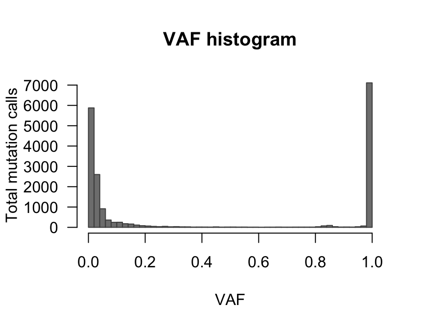

```r
major = mutations[mutations$consensus,] # Referred to as consensus variants in the manuscript
withinhost = mutations[!mutations$consensus,] # Referred to as within-host variants in the manuscript

#dev.new(width=9, height=7); par(mfrow=c(2,3))

h = hist(mutations$vaf, 50, las=1, xlab="VAF", main="VAF histogram", border="grey30", col="grey50", ylab="Total mutation calls")
```

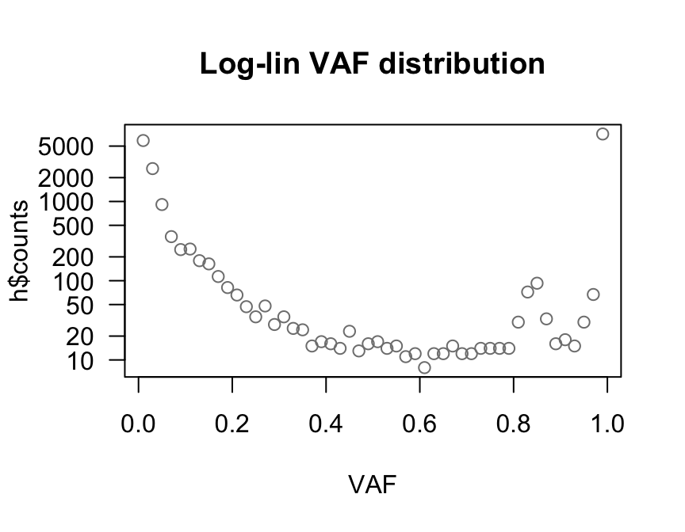

```r
plot(h$mids, h$counts, log="y", las=1, xlab="VAF", main="Log-lin VAF distribution", border="grey30", col="grey50")
```

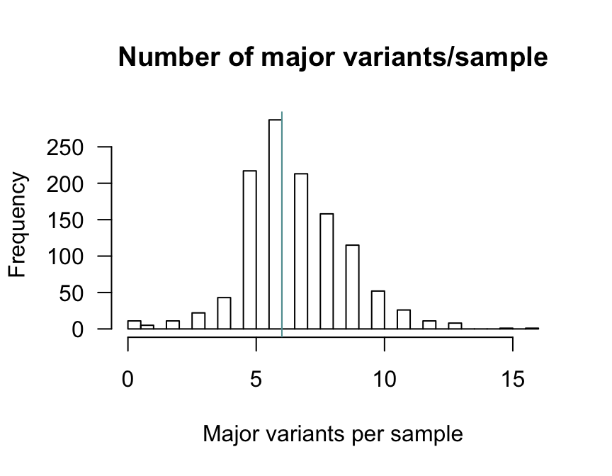

```r
f = table(major$sampleID) # number of major variants per sample
f = c(rep(0,1181-length(f)),f) # appending 0s for samples without withinhost variants
hist(f, 50, las=1, xlab="Major variants per sample", main="Number of major variants/sample")
abline(v=median(f), col="cadetblue")
```

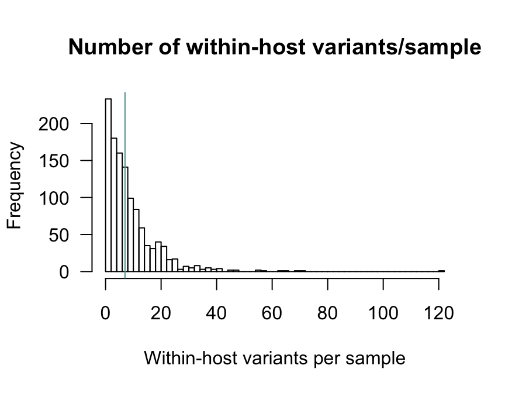

```r
f = table(withinhost$sampleID) # number of within-host variants per sample
f = f[setdiff(names(f),exclude_samples)]
f = c(rep(0,1181-length(f)-length(exclude_samples)),f) # appending 0s for samples without within-host variants
hist(f, 50, las=1, xlab="Within-host variants per sample", main="Number of within-host variants/sample")
abline(v=median(f), col="cadetblue")
```

```r
msplitsc = split(withinhost, f=withinhost$sampleID)
scburden_pervirion = c(rep(0,1181-length(msplitsc)), sapply(msplitsc, function(x) sum(x$vaf)))
print(sprintf("Lower bound estimate of the withinhost burden per virion: mean=%0.2g, median=%0.2g",mean(scburden_pervirion),median(scburden_pervirion)))
```

```
## [1] "Lower bound estimate of the withinhost burden per virion: mean=0.36, median=0.25"
```

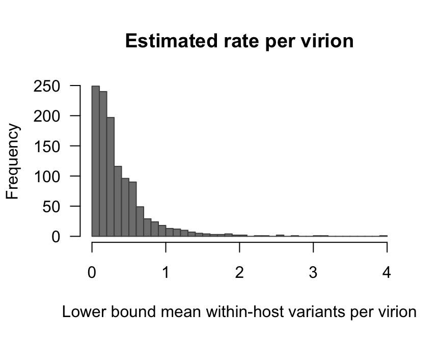

```r
hist(scburden_pervirion, 50, las=1, xlab="Lower bound mean within-host variants per virion", main="Estimated rate per virion", border="grey30", col="grey50")
```

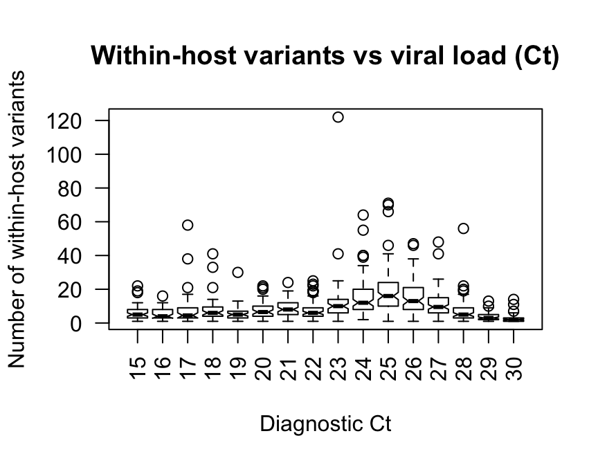

```r
ct = setNames(as.numeric(meta$diagnostic_ct_value), meta$sample_id)
boxplot(f~pmin(30,pmax(15,ct[names(f)])), notch=T, las=2, main="Within-host variants vs viral load (Ct)", xlab="Diagnostic Ct", ylab="Number of within-host variants")
```

```r
#dev.copy(pdf, file="Shearwater_burden_plots.pdf", width=9, height=7, useDingbats=F); dev.off(); dev.off()
```

####Mutational spectra of within-host and major variants

The mutational spectra reveals limited sequence context dependency and a dominance of C>T and G>T changes in the + strand, with strong strand asymmetries. The spectra could be consistent with damage or RNA-editing of cytosines and guanines, possibly including spontaneous cytosine deamination and guanine oxidation. The weakness of the sequence dependence, in stark contrast to known APOBEC-induced mutations in human DNA, might argue against enzymatic RNA-editing.

Plotting the spectrum of unique major variants.

```r
source("plotspectra_96_192.R")

trinfreq = table(sapply(2:(length(genome)-1), function(x) paste(toupper(genome[(x-1):(x+1)]),collapse=""))) # Genome trinucleotide frequency
trinucs = paste(rep(nts,each=16,times=1),rep(nts,each=4,times=4),rep(nts,each=1,times=16), sep="")
trinfreq = trinfreq[trinucs]; trinfreq[is.na(trinfreq)] = 0; names(trinfreq) = trinucs
#dev.new(width=9,height=4.5)
m = unique(major[,c("chr","pos","ref","mut","context")])
plotspectrum192(m, pdfname="./data/reprocessed/major_spectrum.pdf", trinfreqs=trinfreq, plottype=1); dev.off(); dev.off()
plotspectrum12(m, pdfname="./data/reprocessed/major_spectrum12.pdf", trinfreqs=trinfreq, ymax=0.6); dev.off(); dev.off()
plotspectrum192(m, pdfname="./data/reprocessed/major_spectrum_unnormalised.pdf", trinfreqs=NULL, plottype=1); dev.off(); dev.off()

m$sampleID = "sarscov2"; m = m[,c("sampleID","chr","pos","ref","mut")]
dndsout_major = dndscv(m, refdb = "./data/RefCDS_MN908947.3.peptides.rda", max_muts_per_gene_per_sample = Inf, max_coding_muts_per_sample = Inf, cv = NULL)
```

Plotting the spectrum of unique within-host variants.

```r
#dev.new(width=9,height=5)
m = unique(withinhost[,c("chr","pos","ref","mut","context")])
plotspectrum192(m, pdfname="./data/reprocessed/withinhost_spectrum.pdf", trinfreqs=trinfreq, plottype=1); dev.off(); dev.off()
plotspectrum12(m, pdfname="./data/reprocessed/withinhost_spectrum12.pdf", trinfreqs=trinfreq, ymax=0.6); dev.off(); dev.off()
plotspectrum192(m, pdfname="./data/reprocessed/withinhost_spectrum_unnormalised.pdf", trinfreqs=NULL, plottype=1); dev.off(); dev.off()

m$sampleID = "sarscov2"; m = m[,c("sampleID","chr","pos","ref","mut")]
dndsout_withinhost1 = dndscv(m, refdb = "./data/RefCDS_MN908947.3.peptides.rda", max_muts_per_gene_per_sample = Inf, max_coding_muts_per_sample = Inf, outp = 1)
```

Unlike major variants, which are shared across samples due to the phylogenetic relationship among samples, within-host variants shared across samples seem to be largely independently recurrent events. Counting each of them only once artificially flattens the normalised mutation spectrum. We can reduce this distortion by allowing sites to be mutated a maximum number of times (e.g. 5). This avoids a few highly recurrent sites from dominating the spectrum.

```r
maxtimes = 5
withinhost$mutstr = paste(withinhost$pos, withinhost$ref, withinhost$mut, sep="_")
subcspl = split(withinhost, f=withinhost$mutstr)
for (j in 1:length(subcspl)) { subcspl[[j]] = subcspl[[j]][1:min(nrow(subcspl[[j]]),maxtimes),] }
subcspl = do.call("rbind", subcspl)
#dev.new(width=9,height=5)
m = subcspl[,c("chr","pos","ref","mut","context")]
plotspectrum192(m, pdfname="./data/reprocessed/withinhost_spectrum_max5timespermutation.pdf", trinfreqs=trinfreq, plottype=1); dev.off(); dev.off()
plotspectrum12(m, pdfname="./data/reprocessed/withinhost_spectrum_max5timespermutation12.pdf", trinfreqs=trinfreq, ymax=0.6); dev.off(); dev.off()
plotspectrum192(m, pdfname="./data/reprocessed/withinhost_spectrum_max5timespermutation_unnormalised.pdf", trinfreqs=NULL, plottype=1); dev.off(); dev.off()

m$sampleID = paste("sarscov2", 1:nrow(m), sep=":"); m = m[,c("sampleID","chr","pos","ref","mut")]
dndsout_withinhost2 = dndscv(m, refdb = "./data/RefCDS_MN908947.3.peptides.rda", max_muts_per_gene_per_sample = Inf, max_coding_muts_per_sample = Inf)
```

Rate ratio of the plus/minus strands for C>U vs G>U normalised by sequence composition, as shown in the main text.

```r
m = mutations[!mutations$consensus,]
f = table(paste(m$ref[m$ref %in% nts & m$mut %in% nts],m$mut[m$ref %in% nts & m$mut %in% nts],sep=">")); f = f/sum(f)
print((f["C>T"]/table(genome)["C"]) / (f["G>A"]/table(genome)["G"]))
```

```
##      C>T
## 9.869062
```

```r
print((f["G>T"]/table(genome)["G"]) / (f["C>A"]/table(genome)["C"]))
```

```
##      G>T
## 6.970312
```

We can also investigate the spectrum of apparent hypermutable sites.

```r
mintimes = 5
withinhost$mutfreq = table(withinhost$mutstr)[withinhost$mutstr]
recurrsites = unique(withinhost[withinhost$mutfreq>=mintimes, c("pos","ref","mut","context")])
#dev.new(width=9,height=5)
plotspectrum192(recurrsites, pdfname="./data/reprocessed/withinhost_spectrum_recurrsites.pdf", trinfreqs=trinfreq, plottype=1); dev.off(); dev.off()
plotspectrum12(recurrsites, pdfname="./data/reprocessed/withinhost_spectrum_recurrsites12.pdf", trinfreqs=trinfreq); dev.off(); dev.off()
plotspectrum192(recurrsites, pdfname="./data/reprocessed/withinhost_spectrum_recurrsites_unnormalised.pdf", trinfreqs=NULL, plottype=1); dev.off(); dev.off()

m = recurrsites; m$chr = "MN908947.3"; m$sampleID = "sarscov2"; m = m[,c("sampleID","chr","pos","ref","mut")]
dndsout_recurr = dndscv(m, refdb = "./data/RefCDS_MN908947.3.peptides.rda", max_muts_per_gene_per_sample = Inf, max_coding_muts_per_sample = Inf)
```

```r
recurrsites$extctx = sapply(recurrsites$pos, function(x) paste(genome[(x-5):(x+5)],collapse="")) # Extended sequence context
#cat(paste(recurrsites$extctx[recurrsites$ref=="C" & recurrsites$mut=="T"], collapse="\n"))
```

We can calculate separate dN/dS ratios for within-host variants at low and high VAFs. As expected, dN/dS ratios are lower the higher the minimum VAF cutoff.

```r
s = withinhost[withinhost$vaf>0.10,]
maxtimes = 5
subcspl = split(s, f=s$mutstr)
for (j in 1:length(subcspl)) { subcspl[[j]] = subcspl[[j]][1:min(nrow(subcspl[[j]]),maxtimes),] }
subcspl = do.call("rbind", subcspl)
m = subcspl[,c("chr","pos","ref","mut","context")]
m$sampleID = paste("sarscov2", 1:nrow(m), sep=":"); m = m[,c("sampleID","chr","pos","ref","mut")]
dndsout_withinhost3 = dndscv(m, refdb = "./data/RefCDS_MN908947.3.peptides.rda", max_muts_per_gene_per_sample = Inf, max_coding_muts_per_sample = Inf, outp = 1)
```

####dN/dS ratios for within-host and major variants

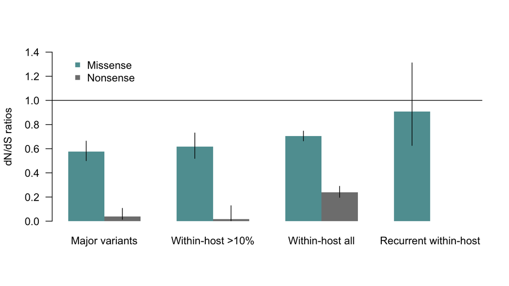

```r
# Plot dN/dS ratios
#dev.new(width=10,height=5); par(mfrow=c(1,2))

d1 = dndsout_major$globaldnds[1:2,2:4]
d2 = dndsout_withinhost3$globaldnds[1:2,2:4]
d3 = dndsout_withinhost2$globaldnds[1:2,2:4]
d4 = dndsout_recurr$globaldnds[1:2,2:4]
h = barplot(cbind(d1[,1],d2[,1],d3[,1],d4[,1]), beside=T, ylim=c(0,1.4), col=c("cadetblue","grey50"), border=NA, las=1, ylab="dN/dS ratios", names=c("Major variants","Within-host >10%","Within-host all","Recurrent within-host"))
segments(x0=h, y0=cbind(d1[,2],d2[,2],d3[,2],d4[,2]), y1=cbind(d1[,3],d2[,3],d3[,3],d4[,3]))
legend(x=1, y=1.4, legend=c("Missense","Nonsense"), col=c("cadetblue","grey50"), pch=15, box.col="white")
abline(h=1, col="black")
```

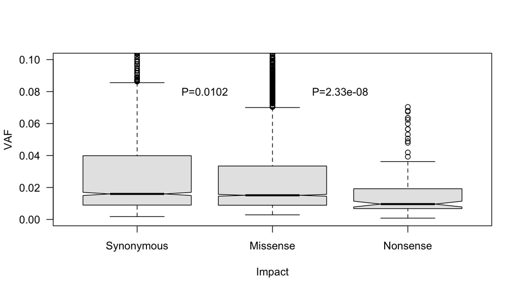

```r
withinhost$impbp = factor(withinhost$impact, levels = c("Synonymous","Missense","Nonsense"))
boxplot(vaf ~ impbp, ylim=c(0,0.1), data = withinhost[withinhost$impact %in% c("Synonymous","Missense","Nonsense"), ], las=1, notch=T, col="grey90", ylab="VAF", xlab="Impact")
withinhost$impbp = NULL
pmis = wilcox.test(withinhost$vaf[withinhost$impact=="Synonymous"], withinhost$vaf[withinhost$impact=="Missense"])$p.value
pnon = wilcox.test(withinhost$vaf[withinhost$impact=="Synonymous"], withinhost$vaf[withinhost$impact=="Nonsense"])$p.value
text(x=c(1.5,2.5), y=0.08, labels=c(sprintf("P=%0.3g",pmis),sprintf("P=%0.3g",pnon)))
```

```r
#dev.copy(pdf, file="Shearwater_selection_plots_dNdS_vafs.pdf", width=10, height=5, useDingbats=F); dev.off(); dev.off()
print(sprintf("P-values VAF of missense or nonsense mutations vs synonymous: pmis=%0.3g, pnon=%0.3g", pmis, pnon))
```

```
## [1] "P-values VAF of missense or nonsense mutations vs synonymous: pmis=0.0102, pnon=2.33e-08"
```

####Annotation of the support for the reference base

```r
# Loading the mutant calls
counts1 = readRDS("run_1_coverage.rds")
counts2 = readRDS("run_2_coverage.rds")
countsall = counts1[,,1:6] + counts1[,,7:12] + counts2[,,1:6] + counts2[,,7:12]
counts_samplids = read.table("./data/sample_list_1181.tsv", header=0, sep="\t", stringsAsFactors=F)[,1]
counts_nts = c("A","T","C","G","-","INS")
ntids = setNames(1:6,counts_nts)
mutations$ref1 = ntids[substr(mutations$ref,1,1)]
mutations$vaf_ref = NA
for (j in 1:nrow(mutations)) {
    x = countsall[which(mutations$sampleID[j]==counts_samplids), mutations$pos[j], ]
    mutations$vaf_ref[j] = x[mutations$ref1[j]] / sum(x)
}
mutations = mutations[, setdiff(colnames(mutations),"ref1")]
write.table(mutations, file="./data/reprocessed/Shearwater_calls_20200714_annot.txt", col.names=T, row.names=F, sep="\t", quote=F)
```

####Distribution of recurrent intrahost mutations

We can first plot the position and frequency of recurrent intrahost variants across the viral genome, and then calculate the number of different genomic backgrounds (as defined by the set of major variants) in which they occur.

```r
withinhost$mutstr = paste(withinhost$pos)
mintimes = 5
numsamples = 1181-length(exclude_samples)
withinhost$nsamples = table(withinhost$pos)[withinhost$mutstr]
recurrsites = unique(withinhost[withinhost$mutfreq>=mintimes, c("pos","nsamples")])
recurrsites = recurrsites[order(recurrsites$pos),]
recurrsites$mutfreq = recurrsites$nsamples / numsamples * 100

# Loading the genome annotation table
reftable = read.table("Reftable_MN908947.3_peptide_resolution.txt", header=1, sep="\t", stringsAsFactors=F, quote = "\"", na.strings = "-", fill = TRUE)
orf = sapply(strsplit(reftable$gene.name, split=":"), function(x) x[1])
library(RColorBrewer)
v = c(brewer.pal(8,"Set2"),brewer.pal(8,"Dark2"))
colvec = setNames(v[1:length(unique(orf))], unique(orf))
reftable$col = colvec[orf]
reftable$height = rep(c(-1,0), length.out=nrow(reftable))

#dev.new(width=8, height=8); par(mfrow=c(3,1))

# 1. Genome structure: ORFs and peptides
plot(NA, xlim=c(1,length(genome)), ylim=c(-5,5), axes=F, xlab="", ylab="")
for (j in 1:nrow(reftable)) {
    rect(xleft=reftable$chr.coding.start[j], xright=reftable$chr.coding.end[j], ybottom=reftable$height[j], ytop=reftable$height[j]+1, border=NA, col=reftable$col[j])
}

# 2. Distribution of recurrent mutations per sample
plot(NA, xlim=c(1,length(genome)), ylim=c(min(recurrsites$mutfreq),max(recurrsites$mutfreq)), log="y", las=1, xlab="Genome position", ylab="% samples")
segments(x0=recurrsites$pos, y0=min(recurrsites$mutfreq/10), y1=recurrsites$mutfreq)

# 3. Distribution of recurrent mutations per unique major genotype
aux = split(major[major$consensus,], f=major$sampleID[major$consensus])
major_bkgs = sapply(aux, function(x) paste(sort(paste(x$pos,x$ref,x$mut,sep=":")),collapse=","))
withinhost$major_bkgs = major_bkgs[withinhost$sampleID]
recurrsites$nbkgs = sapply(recurrsites$pos, function(x) length(unique(withinhost$major_bkgs[withinhost$pos==x])))
recurrsites$nbkgs_freq = recurrsites$nbkgs / length(unique(major_bkgs)) * 100

plot(NA, xlim=c(1,length(genome)), ylim=c(min(recurrsites$mutfreq),max(recurrsites$mutfreq)), log="y", las=1, xlab="Genome position", ylab="% of genomic backgrounds")
segments(x0=recurrsites$pos, y0=min(recurrsites$nbkgs_freq), y1=recurrsites$nbkgs_freq)

#dev.copy(pdf, file="Genomewide_distribution_recurrent_sites.pdf", width=8, height=8, useDingbats=F); dev.off(); dev.off()
```

[output not shown]

####Dataset summary plot (Fig 1)

We can randomly choose 100 samples to show the typical numbers of major and within-host variants per sample, and the VAFs of the mutations.

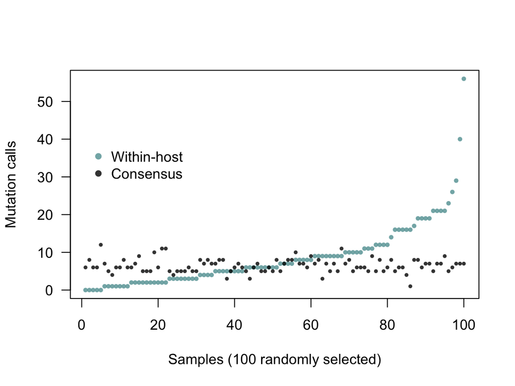

```r
sub_types = c("A>C","A>G","A>T","C>A","C>G","C>T","Indels+MNVs")
colvec = setNames(c("brown3","darkorange2","darkgreen","royalblue3","darkslategray3","darkorchid4","grey50"), sub_types)
mt = c("A>C"=1, "T>G"=1, "A>G"=2, "T>C"=2, "A>T"=3, "T>A"=3, "C>A"=4, "G>T"=4, "C>G"=5, "G>C"=5, "C>T"=6, "G>A"=6)
mutations$muts_type = as.numeric(mt[paste(mutations$ref, mutations$mut, sep=">")])
mutations$muts_type[is.na(mutations$muts_type)] = 7
mutations$muts_col = adjustcolor(colvec[mutations$muts_type], alpha.f=0.7)
# Selecting 100 samples
n = 100 # Number of samples to represent
set.seed(123)
s = sample(setdiff(samples, exclude_samples), size=n, replace=F)
m = split(mutations, f=mutations$sampleID)[s]
m = m[order(sapply(m, function(x) sum(!x$consensus)))] # Sorting by the number of within-host mutations

#dev.new(width=8, height=7.5); par(mfrow=c(2,1))

plot(x=1:n, y=sapply(m, function(x) sum(!x$consensus)), xlab=sprintf("Samples (%0.0f randomly selected)",n), ylab="Mutation calls",
     col=adjustcolor("cadetblue", alpha.f=0.8), pch=16, las=1, cex=0.7)
points(x=1:n, y=sapply(m, function(x) sum(x$consensus)), pch=16, cex=0.6, col=adjustcolor("black", alpha.f=0.8))
legend(x=1, y=40, legend=c("Within-host","Consensus"), pch=16, col=adjustcolor(c("cadetblue","black"), alpha.f=0.8), box.col="white")
```

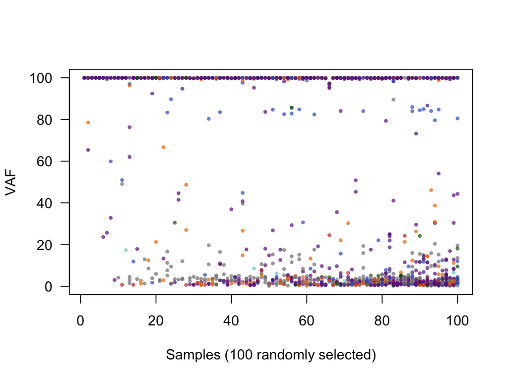

```r
plot(x=1:n, y=rep(NA,n), ylim=c(0,100), xlab=sprintf("Samples (%0.0f randomly selected)",n), ylab="VAF", las=1)
for (j in 1:length(m)) {
    if (length(m[[j]]$vaf)>0) {
        points(x=rep(j,nrow(m[[j]])), y=m[[j]]$vaf*100, col=m[[j]]$muts_col, cex=0.6, pch=16)
    }
}
```

```r
#dev.copy(pdf, file="fig_1ab.pdf", width=8, height=7.5, useDingbats=F); dev.off(); dev.off()
```

####Analysis of possible positively selected sites

Spike protein D614G mutation.

```r
wilcox.test(withinhost$vaf[which(withinhost$aachange=="D614G" & withinhost$pos==23403)], withinhost$vaf[which(withinhost$aachange!="D614G" & withinhost$pos %in% recurrsites$pos)])
```

```
##
##  Wilcoxon rank sum test with continuity correction
##
## data:  withinhost$vaf[which(withinhost$aachange == "D614G" & withinhost$pos ==  and withinhost$vaf[which(withinhost$aachange != "D614G" & withinhost$pos %in%     23403)] and     recurrsites$pos)]
## W = 10320, p-value = 0.2456
## alternative hypothesis: true location shift is not equal to 0
```

```r
median(withinhost$vaf[which(withinhost$aachange=="D614G" & withinhost$pos==23403)])
```

```
## [1] 0.05002629
```

```r
median(withinhost$vaf[which(withinhost$aachange!="D614G" & withinhost$pos %in% recurrsites$pos)])
```

```
## [1] 0.03291282
```

####Allele frequencies of individuals sampled multiple times

We can also study the variation in allele frequencies between samples from different days from the same individual.

```r
metamult = meta[which(meta$biosample_sources!="" & meta$diagnostic_ct_value<24), ]
metamult = metamult[order(metamult$collection_date), ]
metamult = split(metamult, f=metamult$biosample_sources)
metamult = metamult[sapply(metamult, nrow)>1]
```